# Discrete Probability Distributions

Rajitha M. Silva

# Topic 4: Discrete Probability Distributions

This topic introduces discrete random variables and discrete probability distributions. Students will learn how to identify discrete random variables, construct probability distributions, calculate probabilities, and interpret results in practical data science and business analytics problems.

In business and data science, many variables are counts. For example:

- number of customers arriving at a counter;
- number of products returned in a day;
- number of defective items in a batch;
- number of successful sales calls;
- number of loan defaults;
- number of complaints received;
- number of clicks on an advertisement;
- number of fraud alerts.

These variables take separate countable values. Therefore, they are modeled using discrete random variables and discrete probability distributions.

The purpose of this topic is to help students understand how discrete probability models can be used to describe uncertain count-based outcomes.

## Discrete Random Variables

A random variable is a numerical value assigned to the outcome of a random experiment.

A discrete random variable is a random variable that takes countable values.

The values may be finite or countably infinite.

### Examples

The following are examples of discrete random variables:

- number of customers entering a shop in one hour;
- number of defective items in a sample;
- number of successful marketing calls out of 20 calls;
- number of complaints received in a day;
- number of students absent from a class;
- number of times a customer buys a product in a month.

### Non-Examples

The following are not discrete random variables. They are continuous random variables:

- delivery time;
- customer waiting time;
- monthly income;
- body weight;
- temperature;
- product lifetime.

These variables can take values over intervals.

### Practical Example

Suppose a call centre receives customer complaints. Let:

$$X = \text{number of complaints received in one hour}$$

Possible values of $X$ are:

$$0,\ 1,\ 2,\ 3,\ldots$$

Since the number of complaints is a count, $X$ is a discrete random variable.

### Activity 4.1

For each variable, state whether it is discrete or continuous.

1. Number of customers who buy a product in a day.
2. Time taken to deliver an order.
3. Number of defective items in a sample of 50 items.
4. Monthly spending of a customer.
5. Number of loan defaults among 100 customers.
6. Waiting time at a bank counter.

**Solution**

1. Discrete, because it is a count.
2. Continuous, because time can take values over an interval.
3. Discrete, because it is a count.
4. Continuous, because spending can be measured over an interval.
5. Discrete, because it is a count.
6. Continuous, because waiting time can take values over an interval.

### Key Message for Students

A discrete random variable counts something. If the possible values are separate countable numbers, the variable is discrete.

## Probability Distribution of a Discrete Random Variable

A probability distribution gives the possible values of a random variable and the probability attached to each value.

For a discrete random variable $X$, the probability distribution lists:

- the possible values of $X$;
- the probability of each value.

### Probability Mass Function

The probability mass function, or pmf, gives the probability that a discrete random variable equals a particular value.

It is written as:

$$P(X = x)$$

or:

$$p(x)$$

### Conditions for a Probability Distribution

For a discrete probability distribution to be valid, two conditions must be satisfied.

First, every probability must be between 0 and 1:

$$0 \leq P(X = x) \leq 1$$

Second, the probabilities must add up to 1:

$$\sum P(X = x) = 1$$

### Example

Suppose $X$ is the number of products returned by a customer in a month.

| $x$ | 0 | 1 | 2 | 3 |
| --- | --- | --- | --- | --- |
| $P(X=x)$ | 0.50 | 0.30 | 0.15 | 0.05 |

This is a valid probability distribution because:

$$0.50 + 0.30 + 0.15 + 0.05 = 1$$

### Interpretation

The probability that a customer returns no products is:

$$P(X=0) = 0.50$$

The probability that a customer returns exactly two products is:

$$P(X=2) = 0.15$$

The probability that a customer returns at least one product is:

$$P(X \geq 1) = P(X=1) + P(X=2) + P(X=3)$$

$$P(X \geq 1) = 0.30 + 0.15 + 0.05 = 0.50$$

Alternatively:

$$P(X \geq 1) = 1 - P(X=0) = 1 - 0.50 = 0.50$$

### Activity 4.2

A random variable $X$ represents the number of complaints received by a company in one day.

| $x$ | 0 | 1 | 2 | 3 | 4 |
| --- | --- | --- | --- | --- | --- |
| $P(X=x)$ | 0.10 | 0.25 | 0.30 | 0.20 | 0.15 |

Answer the following.

1. Is this a valid probability distribution?
2. Find $P(X=2)$.
3. Find $P(X \leq 2)$.
4. Find $P(X > 2)$.
5. Interpret $P(X > 2)$ in words.

**Solution**

The probabilities add to:

$$0.10 + 0.25 + 0.30 + 0.20 + 0.15 = 1.00$$

All probabilities are between 0 and 1. Therefore, this is a valid probability distribution.

$$P(X=2) = 0.30$$

$$P(X \leq 2) = P(X=0) + P(X=1) + P(X=2)$$

$$P(X \leq 2) = 0.10 + 0.25 + 0.30 = 0.65$$

$$P(X > 2) = P(X=3) + P(X=4)$$

$$P(X > 2) = 0.20 + 0.15 = 0.35$$

Interpretation:

There is a 35% chance that the company receives more than two complaints in one day.

## Expected Value of a Discrete Random Variable

The expected value is the long-run average value of a random variable.

For a discrete random variable $X$, the expected value is:

$$E(X) = \sum xP(X=x)$$

The expected value is also called the mean of the random variable.

It is commonly denoted by:

$$\mu$$

### Practical Meaning

The expected value does not necessarily have to be a possible value of the random variable.

For example, the expected number of complaints may be 2.4. This does not mean that exactly 2.4 complaints can occur. It means that the long-run average is 2.4 complaints per period.

### Example

Suppose $X$ is the number of products returned by a customer in a month.

| $x$ | 0 | 1 | 2 | 3 |
| --- | --- | --- | --- | --- |
| $P(X=x)$ | 0.50 | 0.30 | 0.15 | 0.05 |

Then:

$$E(X) = 0(0.50) + 1(0.30) + 2(0.15) + 3(0.05)$$

$$E(X) = 0 + 0.30 + 0.30 + 0.15 = 0.75$$

The expected number of product returns per customer is 0.75.

### Business Interpretation

If the company has many similar customers, the long-run average number of returns is expected to be about 0.75 per customer per month.

This can help the company plan return handling, staffing, and inventory adjustments.

### Activity 4.3

A company records the number of warranty claims per customer.

| $x$ | 0 | 1 | 2 | 3 |
| --- | --- | --- | --- | --- |
| $P(X=x)$ | 0.60 | 0.25 | 0.10 | 0.05 |

Find $E(X)$ and interpret the result.

**Solution**

$$E(X) = 0(0.60) + 1(0.25) + 2(0.10) + 3(0.05)$$

$$E(X) = 0 + 0.25 + 0.20 + 0.15 = 0.60$$

The expected number of warranty claims per customer is 0.60.

Interpretation:

In the long run, the company expects about 0.60 warranty claims per customer.

## Variance and Standard Deviation of a Discrete Random Variable

The variance measures how much the values of a random variable vary around the expected value.

For a discrete random variable:

$$Var(X) = E[(X-\mu)^2]$$

where:

$$\mu = E(X)$$

An equivalent formula is:

$$Var(X) = E(X^2) - [E(X)]^2$$

where:

$$E(X^2) = \sum x^2P(X=x)$$

The standard deviation is:

$$SD(X) = \sqrt{Var(X)}$$

### Practical Meaning

The expected value tells us the average outcome.

The variance and standard deviation tell us how much uncertainty or variation exists around that average.

In business analytics, a larger standard deviation means less predictable outcomes.

### Example

Suppose $X$ is the number of products returned by a customer in a month.

| $x$ | 0 | 1 | 2 | 3 |
| --- | --- | --- | --- | --- |
| $P(X=x)$ | 0.50 | 0.30 | 0.15 | 0.05 |

We already found:

$$E(X) = 0.75$$

Now calculate:

$$E(X^2) = 0^2(0.50) + 1^2(0.30) + 2^2(0.15) + 3^2(0.05)$$

$$E(X^2) = 0 + 0.30 + 0.60 + 0.45 = 1.35$$

Therefore:

$$Var(X) = E(X^2) - [E(X)]^2$$

$$Var(X) = 1.35 - (0.75)^2$$

$$Var(X) = 1.35 - 0.5625 = 0.7875$$

The standard deviation is:

$$SD(X) = \sqrt{0.7875} = 0.8874$$

### Business Interpretation

The average number of returns is 0.75, and the standard deviation is about 0.89.

This gives the company an idea of the typical variation in returns from customer to customer.

### Activity 4.4

For the warranty claim distribution below:

| $x$ | 0 | 1 | 2 | 3 |
| --- | --- | --- | --- | --- |
| $P(X=x)$ | 0.60 | 0.25 | 0.10 | 0.05 |

Find:

1. $E(X^2)$
2. $Var(X)$
3. $SD(X)$

Use the value $E(X)=0.60$ from Activity 4.3.

**Solution**

Calculate $E(X^2)$:

$$E(X^2) = 0^2(0.60) + 1^2(0.25) + 2^2(0.10) + 3^2(0.05)$$

$$E(X^2) = 0 + 0.25 + 0.40 + 0.45 = 1.10$$

Now:

$$Var(X) = E(X^2) - [E(X)]^2$$

$$Var(X) = 1.10 - (0.60)^2$$

$$Var(X) = 1.10 - 0.36 = 0.74$$

Therefore:

$$SD(X) = \sqrt{0.74} = 0.8602$$

## Bernoulli Distribution

A Bernoulli distribution is used when there are only two possible outcomes.

These outcomes are often called:

- success;
- failure.

A Bernoulli random variable takes values:

$$X = 1$$

for success, and:

$$X = 0$$

for failure.

If the probability of success is $p$, then:

$$P(X=1) = p$$

and:

$$P(X=0) = 1-p$$

We write:

$$X \sim Bernoulli(p)$$

### Expected Value and Variance

For a Bernoulli random variable:

$$E(X) = p$$

and:

$$Var(X) = p(1-p)$$

### Business Analytics Example

Suppose a customer either purchases or does not purchase after clicking an advertisement.

Let:

$$X =
\begin{cases}
1, & \text{if the customer purchases} \\
0, & \text{if the customer does not purchase}
\end{cases}$$

If the probability of purchase is:

$$p = 0.20$$

then:

$$X \sim Bernoulli(0.20)$$

The expected value is:

$$E(X) = 0.20$$

The variance is:

$$Var(X) = 0.20(0.80) = 0.16$$

### Interpretation

The expected value 0.20 means that the long-run purchase rate is 20%.

This does not mean a single customer purchases 0.20 times. It means that over many similar customers, about 20% are expected to purchase.

### Activity 4.5

A loan applicant either defaults or does not default.

Let:

$$X =
\begin{cases}
1, & \text{if the applicant defaults} \\
0, & \text{if the applicant does not default}
\end{cases}$$

Suppose:

$$P(X=1)=0.08$$

Find:

1. $P(X=0)$
2. $E(X)$
3. $Var(X)$
4. Interpret $E(X)$.

**Solution**

Since $P(X=1)=0.08$:

$$P(X=0) = 1 - 0.08 = 0.92$$

The expected value is:

$$E(X) = p = 0.08$$

The variance is:

$$Var(X) = p(1-p) = 0.08(0.92)$$

$$Var(X) = 0.0736$$

Interpretation:

The expected value 0.08 means that the long-run default rate is 8%.

## Binomial Distribution

The binomial distribution is used to model the number of successes in a fixed number of independent Bernoulli trials.

A binomial random variable counts how many successes occur.

We write:

$$X \sim Binomial(n,p)$$

where:

- $n$ is the number of trials;
- $p$ is the probability of success in each trial.

### Conditions for the Binomial Distribution

The binomial distribution is appropriate when:

1. there is a fixed number of trials;
2. each trial has two possible outcomes;
3. the probability of success is the same for every trial;
4. the trials are independent;
5. the random variable counts the number of successes.

### Binomial Probability Formula

If:

$$X \sim Binomial(n,p)$$

then:

$$P(X=x) = {n \choose x}p^x(1-p)^{n-x}$$

where:

$${n \choose x} = \frac{n!}{x!(n-x)!}$$

### Expected Value and Variance

For a binomial random variable:

$$E(X) = np$$

and:

$$Var(X) = np(1-p)$$

The standard deviation is:

$$SD(X) = \sqrt{np(1-p)}$$

### Business Analytics Example

Suppose a company calls 10 potential customers. Each customer independently has a 0.30 probability of making a purchase.

Let:

$$X = \text{number of customers who make a purchase}$$

Then:

$$X \sim Binomial(10, 0.30)$$

### Probability of Exactly 4 Purchases

We want:

$$P(X=4)$$

Using the binomial formula:

$$P(X=4) = {10 \choose 4}(0.30)^4(0.70)^6$$

Since:

$${10 \choose 4} = 210$$

we get:

$$P(X=4) = 210(0.30)^4(0.70)^6$$

$$P(X=4) = 0.2001$$

approximately.

### Probability of At Least One Purchase

The probability of at least one purchase is:

$$P(X \geq 1)$$

It is easier to use the complement rule:

$$P(X \geq 1) = 1 - P(X=0)$$

Now:

$$P(X=0) = {10 \choose 0}(0.30)^0(0.70)^{10}$$

$$P(X=0) = (0.70)^{10} = 0.0282$$

Therefore:

$$P(X \geq 1) = 1 - 0.0282 = 0.9718$$

### Expected Number of Purchases

$$E(X) = np = 10(0.30) = 3$$

The expected number of purchases is 3.

### Activity 4.6

A digital advertisement is shown to 8 customers. Each customer independently has a 0.25 probability of clicking the advertisement.

Let:

$$X = \text{number of customers who click}$$

Answer the following.

1. State the distribution of $X$.
2. Find $P(X=2)$.
3. Find $P(X=0)$.
4. Find $P(X \geq 1)$.
5. Find $E(X)$.
6. Interpret $E(X)$.

**Solution**

There are 8 independent trials, each with probability of success 0.25.

Therefore:

$$X \sim Binomial(8,0.25)$$

For $P(X=2)$:

$$P(X=2) = {8 \choose 2}(0.25)^2(0.75)^6$$

$${8 \choose 2} = 28$$

So:

$$P(X=2) = 28(0.25)^2(0.75)^6$$

$$P(X=2) = 0.3115$$

approximately.

For $P(X=0)$:

$$P(X=0) = {8 \choose 0}(0.25)^0(0.75)^8$$

$$P(X=0) = 0.75^8 = 0.1001$$

approximately.

For $P(X \geq 1)$:

$$P(X \geq 1) = 1 - P(X=0)$$

$$P(X \geq 1) = 1 - 0.1001 = 0.8999$$

The expected value is:

$$E(X) = np = 8(0.25) = 2$$

Interpretation:

Out of 8 customers, the expected number of clicks is 2.

## Poisson Distribution

The Poisson distribution is used to model the number of times an event occurs in a fixed interval of time, space, area, or volume.

Examples include:

- number of customer arrivals per hour;
- number of website visits per minute;
- number of defects per product batch;
- number of accidents per week;
- number of complaints per day;
- number of system failures per month.

We write:

$$X \sim Poisson(\lambda)$$

where:

$$\lambda$$

is the average number of events in the given interval.

### Poisson Probability Formula

If:

$$X \sim Poisson(\lambda)$$

then:

$$P(X=x) = \frac{e^{-\lambda}\lambda^x}{x!}$$

where:

$$x = 0,1,2,\ldots$$

### Expected Value and Variance

For a Poisson random variable:

$$E(X) = \lambda$$

and:

$$Var(X) = \lambda$$

The standard deviation is:

$$SD(X) = \sqrt{\lambda}$$

### When to Use the Poisson Distribution

Use the Poisson distribution when:

- the random variable counts events;
- events occur in a fixed interval;
- events occur independently;
- the average rate is approximately constant;
- two events do not occur at exactly the same instant in a very small interval.

### Business Analytics Example

Suppose a call centre receives an average of 3 complaints per hour.

Let:

$$X = \text{number of complaints received in one hour}$$

Then:

$$X \sim Poisson(3)$$

### Probability of Exactly 5 Complaints

We want:

$$P(X=5)$$

Using the Poisson formula:

$$P(X=5) = \frac{e^{-3}3^5}{5!}$$

$$P(X=5) = 0.1008$$

approximately.

### Probability of No Complaints

$$P(X=0) = \frac{e^{-3}3^0}{0!}$$

$$P(X=0) = e^{-3} = 0.0498$$

approximately.

### Probability of At Most 2 Complaints

$$P(X \leq 2) = P(X=0) + P(X=1) + P(X=2)$$

$$P(X \leq 2) =
\frac{e^{-3}3^0}{0!} +
\frac{e^{-3}3^1}{1!} +
\frac{e^{-3}3^2}{2!}$$

$$P(X \leq 2) = 0.4232$$

approximately.

### Activity 4.7

A website receives an average of 4 support requests per hour.

Let:

$$X = \text{number of support requests in one hour}$$

Assume:

$$X \sim Poisson(4)$$

Find:

1. $P(X=2)$
2. $P(X=0)$
3. $P(X \leq 2)$
4. $E(X)$
5. $SD(X)$

**Solution**

For $P(X=2)$:

$$P(X=2) = \frac{e^{-4}4^2}{2!}$$

$$P(X=2) = 0.1465$$

approximately.

For $P(X=0)$:

$$P(X=0) = \frac{e^{-4}4^0}{0!}$$

$$P(X=0) = e^{-4} = 0.0183$$

approximately.

For $P(X \leq 2)$:

$$P(X \leq 2) = P(X=0) + P(X=1) + P(X=2)$$

$$P(X \leq 2) = 0.0183 + 0.0733 + 0.1465$$

$$P(X \leq 2) = 0.2381$$

The expected value is:

$$E(X) = \lambda = 4$$

The standard deviation is:

$$SD(X) = \sqrt{4} = 2$$

## Binomial versus Poisson Distribution

Both binomial and Poisson distributions are used for count data, but they are used in different situations.

### Binomial Distribution

Use the binomial distribution when:

- there is a fixed number of trials;
- each trial has success or failure;
- the probability of success is fixed;
- we count the number of successes.

Example:

Number of customers who click an advertisement out of 50 customers.

### Poisson Distribution

Use the Poisson distribution when:

- events occur over a fixed interval;
- there is no fixed number of trials;
- we count the number of events in that interval;
- the average rate is known.

Example:

Number of customer complaints received per hour.

### Practical Comparison

| Situation | Suitable Distribution |
| --- | --- |
| Number of defective items in a sample of 100 items | Binomial |
| Number of calls arriving per hour | Poisson |
| Number of customers who respond to 20 sales calls | Binomial |
| Number of accidents per week | Poisson |
| Number of loan defaults among 500 customers | Binomial |
| Number of website errors per day | Poisson |

### Activity 4.8

For each situation, identify whether the binomial or Poisson distribution is more suitable.

1. Number of customers who buy a product out of 30 contacted customers.
2. Number of website crashes in a month.
3. Number of defective items in a sample of 50 items.
4. Number of calls received by a call centre in one hour.
5. Number of students who pass an exam out of 80 students.

**Solution**

1. Binomial, because there is a fixed number of contacted customers and each customer either buys or does not buy.
2. Poisson, because it counts events over a fixed time interval.
3. Binomial, because there is a fixed sample size and each item is defective or not defective.
4. Poisson, because it counts arrivals over a fixed time interval.
5. Binomial, because there is a fixed number of students and each student either passes or does not pass.

## Integrated Practice and Mini Case Study

This section connects discrete random variables, probability distributions, expected value, binomial distribution, Poisson distribution, and business interpretation.

### Mini Case Study: Online Retail Analytics

An online retailer studies two business problems.

Problem A: Advertisement clicks

The retailer sends a promotional advertisement to 12 customers. Based on past data, each customer has a 0.20 probability of clicking the advertisement. Assume customers behave independently.

Let:

$$X = \text{number of customers who click the advertisement}$$

Problem B: Customer complaints

The retailer receives an average of 2 complaints per day.

Let:

$$Y = \text{number of complaints received in one day}$$

Assume:

$$Y \sim Poisson(2)$$

Answer the following questions.

1. What is the distribution of $X$?
2. Find $P(X=3)$.
3. Find $P(X \geq 1)$.
4. Find $E(X)$.
5. Find $Var(X)$.
6. Find $P(Y=0)$.
7. Find $P(Y \leq 2)$.
8. Find $E(Y)$.
9. Interpret the results for management.

**Solution**

Problem A is binomial because there is a fixed number of customers, each customer either clicks or does not click, and the probability of clicking is constant.

Therefore:

$$X \sim Binomial(12,0.20)$$

For $P(X=3)$:

$$P(X=3) = {12 \choose 3}(0.20)^3(0.80)^9$$

$${12 \choose 3} = 220$$

$$P(X=3) = 220(0.20)^3(0.80)^9$$

$$P(X=3) = 0.2362$$

approximately.

For $P(X \geq 1)$:

$$P(X \geq 1) = 1 - P(X=0)$$

$$P(X=0) = {12 \choose 0}(0.20)^0(0.80)^{12}$$

$$P(X=0) = 0.80^{12} = 0.0687$$

Therefore:

$$P(X \geq 1) = 1 - 0.0687 = 0.9313$$

The expected value is:

$$E(X) = np = 12(0.20) = 2.4$$

The variance is:

$$Var(X) = np(1-p) = 12(0.20)(0.80)$$

$$Var(X) = 1.92$$

For complaints:

$$Y \sim Poisson(2)$$

For $P(Y=0)$:

$$P(Y=0) = \frac{e^{-2}2^0}{0!}$$

$$P(Y=0) = e^{-2} = 0.1353$$

For $P(Y \leq 2)$:

$$P(Y \leq 2) = P(Y=0) + P(Y=1) + P(Y=2)$$

$$P(Y \leq 2)
= \frac{e^{-2}2^0}{0!}
+ \frac{e^{-2}2^1}{1!}
+ \frac{e^{-2}2^2}{2!}$$

$$P(Y \leq 2) = 0.1353 + 0.2707 + 0.2707 = 0.6767$$

The expected value is:

$$E(Y) = \lambda = 2$$

Management interpretation:

The advertisement is expected to generate about 2.4 clicks out of 12 customers. There is a high probability, about 93.13%, of receiving at least one click. For complaints, the company expects about 2 complaints per day, and there is about a 67.67% chance of receiving at most 2 complaints in a day.

## Summary

In this topic, students learned how to identify and work with discrete random variables and discrete probability distributions.

The main ideas covered were:

- discrete random variables;
- probability mass functions;
- valid probability distributions;
- probability calculations using tables;
- expected value;
- variance and standard deviation;
- Bernoulli distribution;
- binomial distribution;
- Poisson distribution;
- choosing between binomial and Poisson models;
- practical interpretation in business analytics.

## Quick Formula Summary

### Valid Probability Distribution

$$0 \leq P(X=x) \leq 1$$

and:

$$\sum P(X=x) = 1$$

### Expected Value

$$E(X) = \sum xP(X=x)$$

### Variance

$$Var(X) = E(X^2) - [E(X)]^2$$

where:

$$E(X^2) = \sum x^2P(X=x)$$

### Standard Deviation

$$SD(X) = \sqrt{Var(X)}$$

### Bernoulli Distribution

$$X \sim Bernoulli(p)$$

$$P(X=1)=p,\quad P(X=0)=1-p$$

$$E(X)=p$$

$$Var(X)=p(1-p)$$

### Binomial Distribution

$$X \sim Binomial(n,p)$$

$$P(X=x) = {n \choose x}p^x(1-p)^{n-x}$$

$$E(X)=np$$

$$Var(X)=np(1-p)$$

### Poisson Distribution

$$X \sim Poisson(\lambda)$$

$$P(X=x) = \frac{e^{-\lambda}\lambda^x}{x!}$$

$$E(X)=\lambda$$

$$Var(X)=\lambda$$

## Suggested End-of-Topic Practice Questions

### Question 1

A random variable $X$ represents the number of defective items in a small sample.

| $x$ | 0 | 1 | 2 | 3 |
| --- | --- | --- | --- | --- |
| $P(X=x)$ | 0.40 | 0.35 | 0.20 | 0.05 |

Find:

1. $P(X=1)$
2. $P(X \leq 1)$
3. $P(X > 1)$
4. $E(X)$

### Question 2

A customer either buys or does not buy a product after receiving an email. The probability of buying is 0.12.

Let $X=1$ if the customer buys and $X=0$ otherwise.

1. State the distribution of $X$.
2. Find $E(X)$.
3. Find $Var(X)$.
4. Interpret $E(X)$.

### Question 3

A company contacts 15 customers. Each customer independently has a 0.20 probability of buying.

Let $X$ be the number of customers who buy.

1. State the distribution of $X$.
2. Find $P(X=3)$.
3. Find $P(X=0)$.
4. Find $P(X \geq 1)$.
5. Find $E(X)$.

### Question 4

A call centre receives an average of 5 calls per minute.

Let $X$ be the number of calls received in one minute.

Assume $X \sim Poisson(5)$.

Find:

1. $P(X=4)$
2. $P(X=0)$
3. $P(X \leq 2)$
4. $E(X)$
5. $SD(X)$

### Question 5

For each situation, state whether Bernoulli, binomial, or Poisson is most suitable.

1. Whether one customer clicks an advertisement.
2. Number of customers who click out of 100 customers.
3. Number of complaints received per day.
4. Whether one loan applicant defaults.
5. Number of defective items in a sample of 30 items.

## Suggested Short R Activity

The following R code can be used to calculate probabilities for discrete distributions.

### Discrete Probability Distribution from a Table

```r
x <- c(0, 1, 2, 3)
prob <- c(0.50, 0.30, 0.15, 0.05)

sum(prob)
```

```
## [1] 1
```

```r
expected_value <- sum(x * prob)
expected_value
```

```
## [1] 0.75
```

```r
expected_x2 <- sum(x^2 * prob)
variance <- expected_x2 - expected_value^2
variance
```

```
## [1] 0.7875
```

```r
standard_deviation <- sqrt(variance)
standard_deviation
```

```
## [1] 0.887412
```

### Binomial Distribution in R

```r
# X ~ Binomial(10, 0.30)

# P(X = 4)
dbinom(4, size = 10, prob = 0.30)
```

```
## [1] 0.2001209
```

```r
# P(X = 0)
dbinom(0, size = 10, prob = 0.30)
```

```
## [1] 0.02824752
```

```r
# P(X >= 1)
1 - dbinom(0, size = 10, prob = 0.30)
```

```
## [1] 0.9717525
```

```r
# P(X <= 4)
pbinom(4, size = 10, prob = 0.30)
```

```
## [1] 0.8497317
```

### Poisson Distribution in R

```r
# X ~ Poisson(3)

# P(X = 5)
dpois(5, lambda = 3)
```

```
## [1] 0.1008188
```

```r
# P(X = 0)
dpois(0, lambda = 3)
```

```
## [1] 0.04978707
```

```r
# P(X <= 2)
ppois(2, lambda = 3)
```

```
## [1] 0.4231901
```

```r
# P(X > 2)
1 - ppois(2, lambda = 3)
```

```
## [1] 0.5768099
```

### Plotting a Binomial Distribution

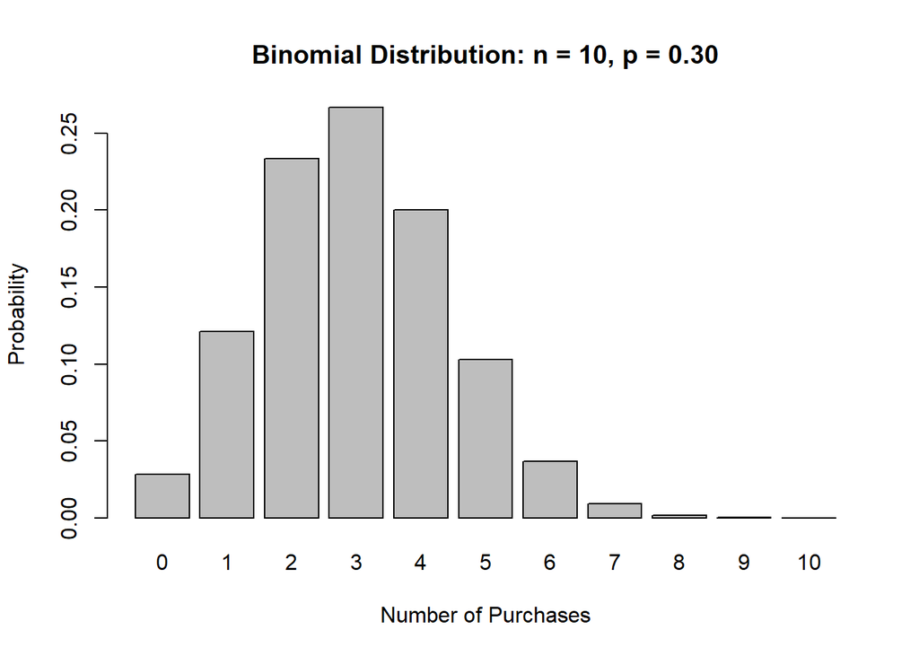

```r
x_values <- 0:10
binomial_probs <- dbinom(x_values, size = 10, prob = 0.30)

barplot(
  binomial_probs,
  names.arg = x_values,
  main = "Binomial Distribution: n = 10, p = 0.30",
  xlab = "Number of Purchases",
  ylab = "Probability"
)
```

### Plotting a Poisson Distribution

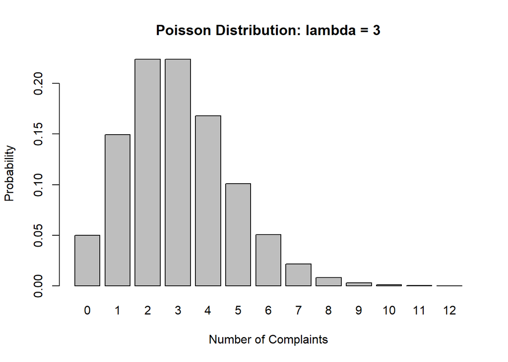

```r
x_values <- 0:12
poisson_probs <- dpois(x_values, lambda = 3)

barplot(
  poisson_probs,
  names.arg = x_values,
  main = "Poisson Distribution: lambda = 3",
  xlab = "Number of Complaints",
  ylab = "Probability"
)
```

## Practical Closing Note for Students

Discrete probability distributions are useful when the outcome is a count.

In data science and business analytics, many important problems involve counting events: purchases, clicks, defaults, complaints, arrivals, defects, and failures.

A good analyst should not only calculate probabilities but also explain what they mean for decision-making.

For example, saying:

$$P(X \geq 1) = 0.9313$$

is not enough.

A better interpretation is:

“There is about a 93.13% chance that at least one customer will click the advertisement among the 12 customers contacted.”

That is the type of interpretation expected in data science and business analytics.